```r
options(jupyter.plot_mimetypes = 'image/png')
```

[figure not shown]

# Krigagem em R

#### Abstract

Nesse documento vamos introduzir a abertura de mapas e o método de Krigagem em linguagem R

## 0.Introdução

A principal motivação deste documento é apresentar um modelo para um processo inicial de análise de dados, desde as etapas de recebimento, leitura e formação de banco de dados. Em todo o relatório, gradativamente, listaremos, passo-a-passo, as ações essenciais para a execução do objetivo, previamente, descrito. Em todo processo, utilizou-se a linguagem de programação R (aberta e gratuita).$\\$

## 0.1 Sobre a linguagem R

O **R** é uma linguagem orientada a objetos, criado por Ross Ihaka e por Robert Gentleman, intensamente utilizada, entre outras ações, para cálculos estatísticos e criação de gráficos. É amplamente utilizado por estar sob licença de Software livre *GPL*,ser multiplataforma (**Linux, Mac, Window**) e também por ser altamente expansível pelo uso de novos pacotes estatísticos criados diariamente por pesquisadores de diversas áreas da ciência. Assim, o **R** é uma linguagem fortemente recomendável para a leitura e tratamento de dados estatísticos.

## 1 Abertura de mapa

## 1.1 sobre o shapefile

O Esri Shapefile ou simplesmente shapefile é um formato popular de arquivo contendo dados geoespaciais em forma de vetor usado por Sistemas de Informações Geográficas também conhecidos como SIG. Foi desenvolvido e regulamentado por Esri como uma especificação aberta para interoperabilidade por dados entre os softwares de Esri e de outros fornecedores.

Shapefiles espacial descrevem geometrias: pontos, linhas, e polígonos. Entre outras coisas, essas geometrias podem representar Poços, Rios, e Lagos, respectivamente. Cada item pode ter atributos que os descrevem, por exemplo: nome, temperatura ou profundidade. $\textit{(Wikipédia)}$

# 3 Abertura de mapas

## 2 Pacotes utilizados

[rgdal](https://cran.r-project.org/web/packages/rgdal/rgdal.pdf) utilizado para fazer a transposição dos dados do arquivo shapefile, para uma tabela de dados espacial (Spatial vector)

[plyr](https://cran.r-project.org/web/packages/plyr/plyr.pdf) pacote para fazer operações com tabelas como: join, merge.

[ggplot2](https://cran.r-project.org/web/packages/sp/sp.pdf) Pacote para a visulizar gráficos mais complexos que o método padrão.

[ggmap](http://journal.r-project.org/archive/2013-1/kahle-wickham.pdf) vizualização do shapefile sobreposta sobre uma imagem satélite

[sp](https://cran.r-project.org/web/packages/sp/sp.pdf) projeta o conjunto de dados espacial, para uma coordenada desejada ou para configurar um mapa para uma base de dado para a vizualização do pacote **ggplot2**

Para instalar os pacotes você deve utilizar o comando:

**install.packages("Nome_do_Pacote")**

e para utilizar os pacotes, use :

**require("Nome_do_pacote_instalado")**

```r
require("rgdal")
require("ggplot2")
require("ggmap")
require("plyr")
require("sp")
```

## 3.1 Método convencional

No método convencional, você visualiza o mapa usando a função convencional **plot**, para baixar o mapa utilizamos os comandos:

- para abrir o arquivo shapefile
  - ogrListLayes()
  - readOGR()
- para mudar as coordenadas de **WGS84** para **Longitude\Latitude**
  - spTransform()
- finalmente plotar e botar um título
  - plot()
  - title()

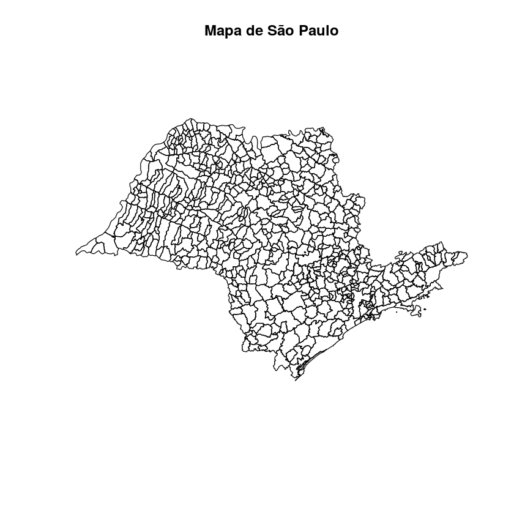

```r
setwd(dir = "./mapa/");
file_map <- "mun_lin.shp";
x<- ogrListLayers(file_map);
sp=readOGR(file_map, layer=x)
sp <-  spTransform(sp, CRS("+proj=longlat +datum=WGS84"));
plot(sp);
title("Mapa de São Paulo")
```

## 3.2 Mapa no ggplot

Dado os comandos anteriores de abertura do shapefile, agora convertemos para o modelo ser apresentado pelo *ggplot2*

```r
sp@data$id = rownames(sp@data)
sp.points  = fortify(sp, region="id")
sp.df      = join(sp.points, sp@data, by="id")
```

criamos uma nova tabela chamada **sp.df** para plotar com ggplot2.

No código abaixo temos:

- ggplot(): inicializa o objeto ggplot
- geom_polygon()
  - data: é a tabela de dados
  - aes : recebe os parâmetros a serem plotados

    ```
    - x,y: recebe o vetor das coordenadas geográficas longitude/latitude
    - group: agrupa cada polígono pela coluna group
    ```

  - fill: pinta cada polígono do mapa com uma cor
  - colour: pinta a borda de cada polígono com uma cor
  - opcional:
    - size: valor numérico em [0,1] que define a largura da linha que cobre o polígono
    - alpha: valor numérico em [0,1] que define a transparência da cor do polígono
- theme_bw(): define o fundo branco do gráfico
- coord_fixed(): ajusta o mapa no gráfico

```r
t <- ggplot()+
 geom_polygon(data=sp.df, aes(long,lat,group = group  ),fill="white",colour="black")+
 ggtitle("Mapa de São Paulo")+
 theme_bw() +
 coord_fixed()
```

```r
jpeg(t,"t.jpg")
```

[output not shown]

## 3.3 Mapa com imagem de satélite

Para plotarmos o gráfico sobre o mapa de **satélite** da região de São Paulo usando o código abaixo, onde bbox são os limites do mapa, em que você quer a área de satélite :

```r
sp@bbox[,1]<-sp@bbox[,1] - 2
sp@bbox[,2]<-sp@bbox[,2] + 2
```

- get_map(): faz a requisição da imagem de satélite para o google

[figure not shown]

```r
map <- get_map(c(sp@bbox),maptype="satellite")
ggmap(map)+
geom_polygon(aes(x = long, y = lat, group=group), alpha= 0,colour="white", fill="white", size = 0.5, data = sp.df)
```

## 4 Processo de krigagem

## 4.1 sobre a krigagem

[geoR](https://cran.r-project.org/web/packages/geoR/geoR.pdf) pacote para utlização de krigagem nos dados

[dplyr](https://cran.r-project.org/web/packages/dplyr/dplyr.pdf) utiliza funções de banco de dados, no nosso caso left

```r
require("geoR")
require("dplyr")
```

carregamos a tabela de dados de série temporal pré calculada:

- codigo: código dos pluviômetros da base de dados
- ano: anos da série temporal, [2013-2015]
- mes: variável numérica de 0 a 12 representando os meses
- latitude e longitude: coordenadas dos pluviômetros
- mm.sum: volume em milímetros de chuva total no período de um mês

```r
serie_temp <- read.csv2("../dados/serie_temporal_mensal.csv")
head(serie_temp)
meses <- c("janeiro","fevereiro","marco","abril","maio","junho",
           "julho","agosto","setembro","outubro","novembro","dezembro")
```

|  | codigo | ano | mes | latitude | longitude | mm.sum |
| --- | --- | --- | --- | --- | --- | --- |
| 1 | 350050101A | 2014 | 12 | -22.475 | -46.628 | 254.4 |
| 2 | 350050101A | 2015 | 1 | -22.475 | -46.628 | 33.8 |
| 3 | 350050101A | 2015 | 2 | -22.475 | -46.628 | 283.2 |
| 4 | 350050101A | 2015 | 3 | -22.475 | -46.628 | 169.6 |
| 5 | 350050102A | 2014 | 12 | -22.482 | -46.593 | 185 |
| 6 | 350050102A | 2015 | 1 | -22.482 | -46.593 | 44.6 |

```r
ano <- 2015
mes <- 1
titulo <- paste(mes,"de",ano,sep=" ")
```

```r
serie <-serie_temp[serie_temp$ano == ano & serie_temp$mes == mes , ]
variaveis <- c("latitude","longitude","mm.sum")
serie <- serie[,variaveis]
head(serie)
```

|  | latitude | longitude | mm.sum |
| --- | --- | --- | --- |
| 2 | -22.475 | -46.628 | 33.8 |
| 6 | -22.482 | -46.593 | 44.6 |
| 10 | -22.704 | -46.818 | 96.9474 |
| 13 | -22.666 | -46.753 | 95.2 |
| 16 | -22.722 | -46.838 | 115.8 |
| 20 | -22.86 | -45.225 | 61.8 |

```r
geodata <- as.geodata(serie,coords.col = c(1,2),data.col = 3)
```

Define os limites dos pontos dos pluviômetros com uma margem de 0.1

```r
xrange <- c(min(geodata[[1]][,1])-0.1,max(geodata[[1]][,1])+0.1)
yrange <- c(min(geodata[[1]][,2])-0.1,max(geodata[[1]][,2])+0.1)
```

Cria a malha com os limites dos pluviômetros com a distância de 0.05 entre eles

```r
grid <- expand.grid(seq(xrange[1],xrange[2],by=.05),seq(yrange[1],yrange[2],by=.05))
```

Calcula o variograma omnidirecional assumindo que a média do erro (u) é:

- 1st : polinômio de 1º grau mu(x) = beta0 + beta1*x1 + beta2*x2.
- 2nd : polinômio de 2º grau μ(x)= beta0 + beta1*x1 + beta2*x2 + beta3*(x1)^2 + beta4*(x2)^2 + beta5*x1*x2.
- cte : é constante

```
variog: computing omnidirectional variogram
```

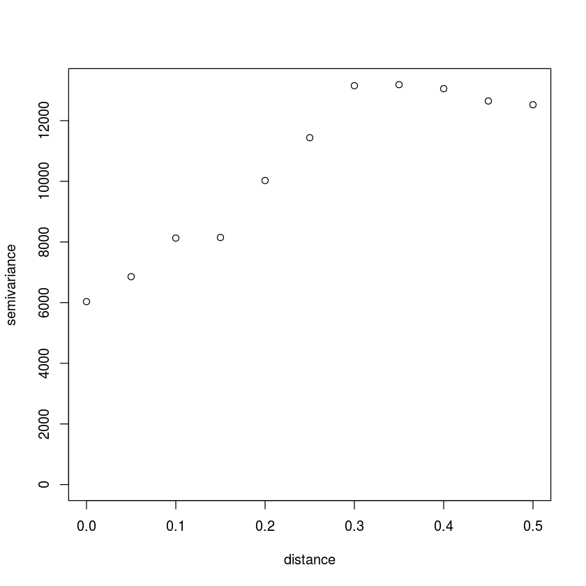

```r
variogram <- variog(geodata, trend="2nd", uvec=seq(0, .5, by=0.05))
plot(variogram)
```

Criamps uma tabela com valores iniciais para estimar a distribuição de milímetros de chuva na área do mapa

```r
initial.values <- expand.grid(seq(min(variogram$v), max(variogram$v), by=10),
                              seq(min(variogram$u), max(variogram$u),by=0.005))
```

os modelos usando a função variofit() podem ser:

- cauchy
- gencauchy
- circular
- cubic
- gaussian
- exponential
- matern
- spherical
- power
- powered.exponential
- gneiting
- gneiting.matern
- wave
- pure.nugget

que podem ser explicados nesse [link](http://www.inside-r.org/packages/cran/geor/docs/cov.spatial)

os parâmetros da função variofit, que estima a distribuição dado o modelo que queremos usar para estimar o semivariograma:

- fix.nugget: recebe operador lógico [TRUE/FALSE], caso FALSE o efeito pepita (**nugget**) é estimado
- nugget: recebe o valor do efeito pepita caso fix.nugget seja igual a TRUE
- ini.cov.pars: recebe a matriz de valores iniciais criadas anteriormente

```
variofit: covariance model used is cubic
variofit: weights used: npairs
variofit: minimisation function used: optim
variofit: searching for best initial value ... selected values:
              sigmasq    phi    tausq kappa
initial.value "12344.39" "0.28" "0"   "0.5"
status        "est"      "est"  "est" "fix"
loss value: 70617633024.5732
```

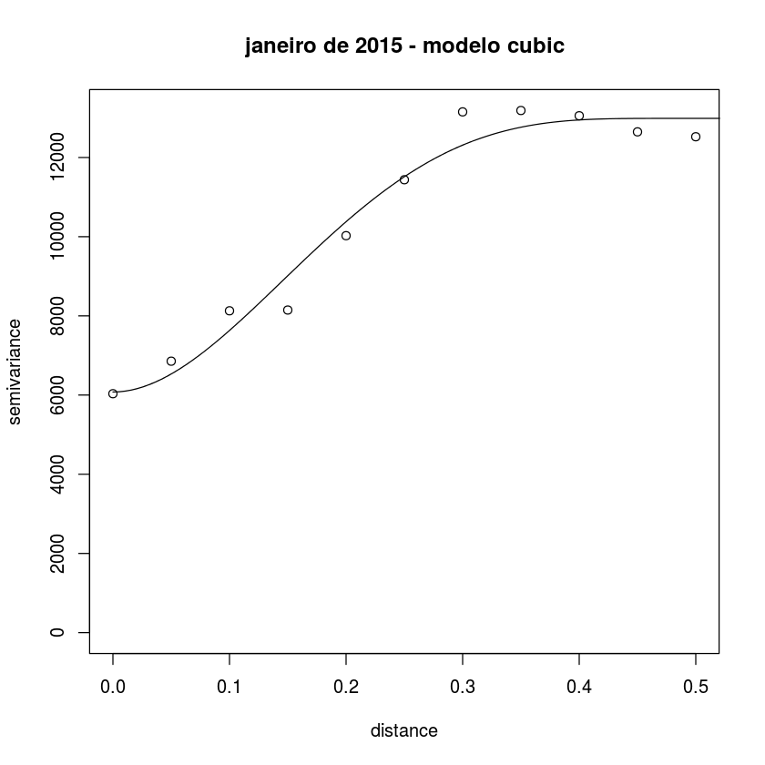

```r
model <- "cubic"
fit <- variofit(variogram, cov.model= model , ini.cov.pars=initial.values,
                    fix.nugget=FALSE)
    plot(variogram)
    title(paste(meses[mes],"de",ano,"-", "modelo", model ))
    lines(fit)
```

Fazendo isso para todos os modelos temos:

```
variog: computing omnidirectional variogram
variofit: covariance model used is matern
variofit: weights used: npairs
variofit: minimisation function used: optim
variofit: searching for best initial value ... selected values:
              sigmasq    phi    tausq kappa
initial.value "13164.39" "0.12" "0"   "0.5"
status        "est"      "est"  "est" "fix"
loss value: 27300110333.2359
variofit: covariance model used is exponential
variofit: weights used: npairs
variofit: minimisation function used: optim
variofit: searching for best initial value ... selected values:
              sigmasq    phi    tausq kappa
initial.value "13164.39" "0.12" "0"   "0.5"
status        "est"      "est"  "est" "fix"
loss value: 27300110333.2359
```

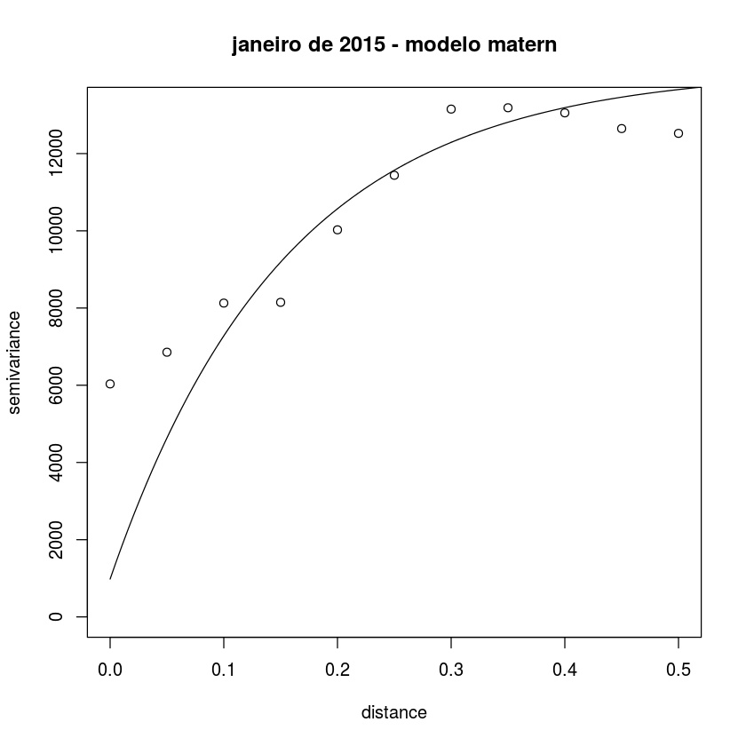

```
variofit: covariance model used is gaussian
variofit: weights used: npairs
variofit: minimisation function used: optim
variofit: searching for best initial value ... selected values:
              sigmasq    phi    tausq kappa
initial.value "12314.39" "0.11" "0"   "0.5"
status        "est"      "est"  "est" "fix"
loss value: 68825447825.3085
```

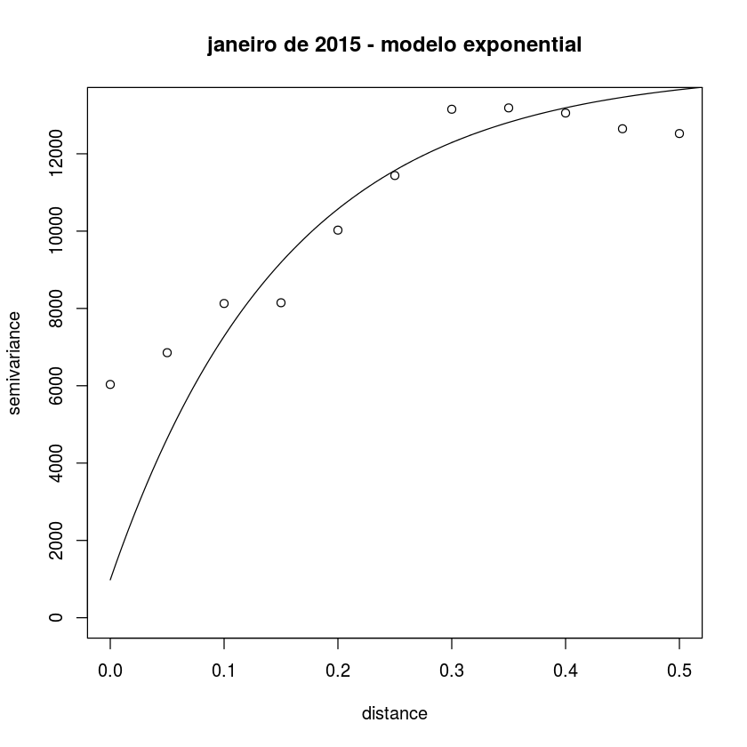

```
variofit: covariance model used is spherical
variofit: weights used: npairs
variofit: minimisation function used: optim
variofit: searching for best initial value ... selected values:
              sigmasq    phi   tausq kappa
initial.value "12754.39" "0.3" "0"   "0.5"
status        "est"      "est" "est" "fix"
loss value: 42323654725.0614
```

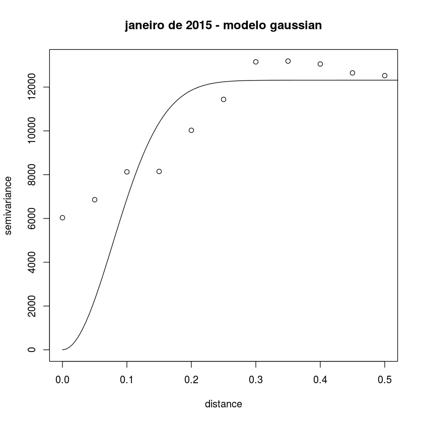

```
variofit: covariance model used is circular
variofit: weights used: npairs
variofit: minimisation function used: optim
variofit: searching for best initial value ... selected values:
              sigmasq    phi    tausq kappa
initial.value "12754.39" "0.26" "0"   "0.5"
status        "est"      "est"  "est" "fix"
loss value: 46664676950.2568
```

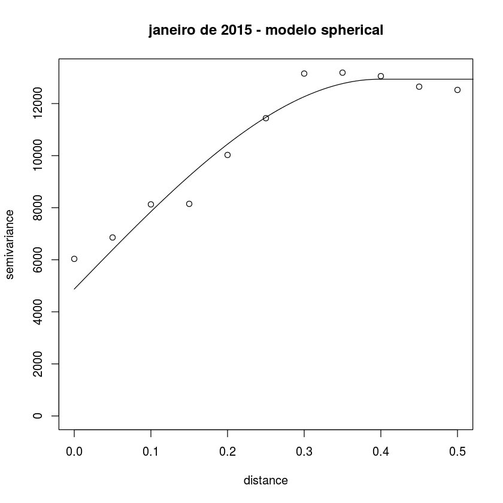

```
variofit: covariance model used is cubic
variofit: weights used: npairs
variofit: minimisation function used: optim
variofit: searching for best initial value ... selected values:
              sigmasq    phi    tausq kappa
initial.value "12344.39" "0.28" "0"   "0.5"
status        "est"      "est"  "est" "fix"
loss value: 70617633024.5732
```

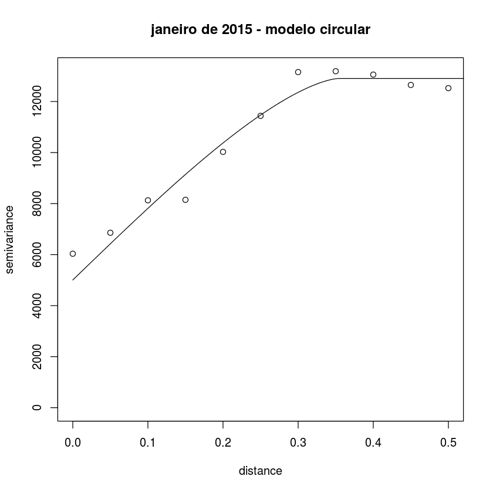

```
variofit: covariance model used is wave
variofit: weights used: npairs
variofit: minimisation function used: optim
variofit: searching for best initial value ... selected values:
              sigmasq    phi   tausq kappa
initial.value "11234.39" "0"   "0"   "0.5"
status        "est"      "est" "est" "fix"
loss value: 119070763736.223
```

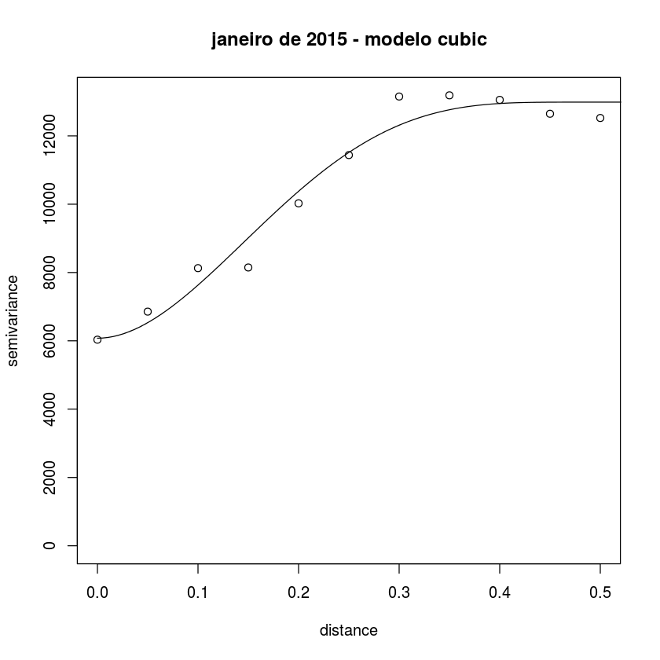

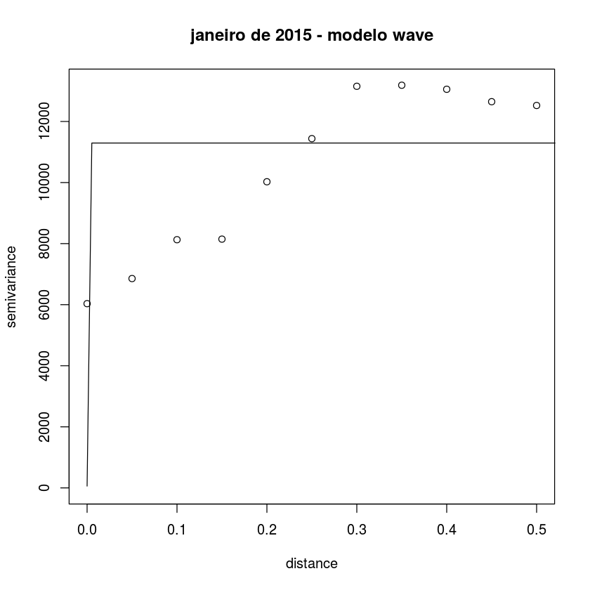

```r
grid <- expand.grid(seq(xrange[1],xrange[2],by=.05),seq(yrange[1],yrange[2],by=.05))



variogram <- variog(geodata, trend="2nd", uvec=seq(0, .5, by=0.05))
plot(variogram)

initial.values <- expand.grid(seq(min(variogram$v), max(variogram$v), by=10),
                              seq(min(variogram$u), max(variogram$u),by=0.005))


models<-c("matern", "exponential", "gaussian",
          "spherical", "circular", "cubic", "wave")
for(model in models){
  fit <- variofit(variogram, cov.model= model , ini.cov.pars=initial.values,
                  fix.nugget=FALSE)
  plot(variogram)
  title(paste(meses[mes],"de",ano,"-", "modelo", model ))
  lines(fit)

}
```

- krige.control:
  - type.krige: podemos utilizar vários tipos de krigagem:
    - *ok*: krigagem normal (ordinária)
    - *sk*: krigagem simples
  - cov.pars: parâmetros estimados pelo modelo
  - nugget : efeito pepita da amostra, no caso

```r
model <- "cubic"
krigagem <- krige.control(type.krige = "ok", cov.model = model,
                          cov.pars = fit$cov.pars,nugget = min(variogram$v))
krigagem2 <- krige.conv(geodata, locations = grid, krige = krigagem)
```

```
krige.conv: model with constant mean
krige.conv: Kriging performed using global neighbourhood
```

contour(), plota o mapa de calor:

[output not shown]

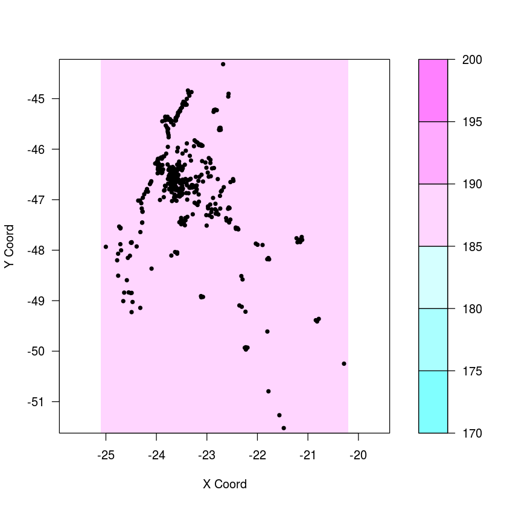

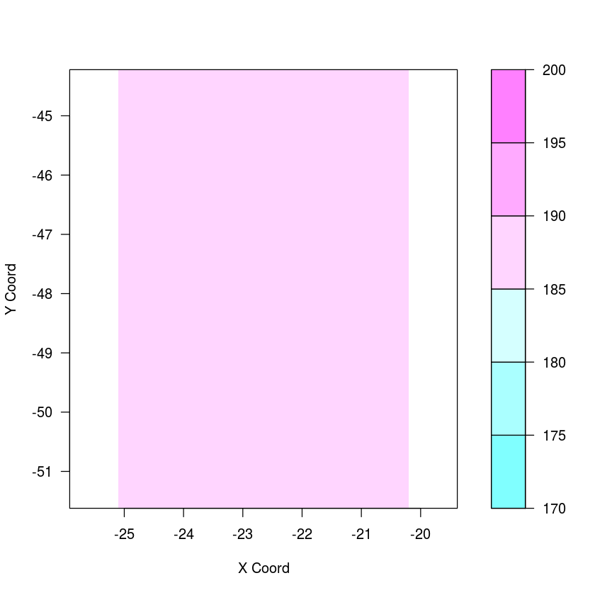

```r
contour(krigagem2,
        filled = TRUE,coords.data = geodata$coords,zlim = c(min(krigagem2$predict),max(krigagem2$predict)))
contour(krigagem2,
        filled = TRUE ,zlim = c(min(krigagem2$predict),max(krigagem2$predict)))
```

cria uma tabela da **malha** das coordenadas e dos valores estimados pela krigagem

```r
malha <- data.frame(grid[,1],grid[,2],krigagem2$predict)
write.csv2(malha,paste("malha","_",model,".csv",sep = ""),row.names = FALSE)
dir()
```

1. 'malha_circular.csv'

2. 'malha_cubic.csv'

3. 'malha_gaussian.csv'

4. 'malha_wave.csv'

5. 'mun_lin.dbf'

6. 'mun_lin.prj'

7. 'mun_lin.shp'

8. 'mun_lin.shx'

9. 'SP.dbf'

10. 'SP.prj'

11. 'SP.shp'

12. 'SP.shx'

13. 'SP_sp.dbf'

14. 'SP_sp.prj'

15. 'SP_sp.shp'

16. 'SP_sp.shx'

Criei a função a seguir para, recebendo um vetor de valores x, devolvemos um vetor de carácteres com faixas referentes aos valores de entrada

```r
cria_faixa<- function (x){
  # x <- seq(0,4000,50)
  faixas <- c(seq(0,250,50),500,1000,2000,Inf)
  ref <-data.frame(matrix(ncol = 2,nrow = length(faixas)))
  names(ref) <-  c("brks","brks2")
  for(i in 1:(length(faixas)-1)){
    if(i + 1 <10  ){
      ref[i,2] <- paste(0,0,i,"-","[",faixas[i],"-",faixas[i+1],"]",sep="")
    }
    else{
      ref[i,2] <- paste(0,i,"-","[",faixas[i],"-",faixas[i+1],"]",sep="")
    }
    ref[i,1]<-paste(faixas[i],"-",faixas[i+1])
  }

  faixa_nova <- data.frame(matrix(ncol = 1,nrow = length(x)))
  names(faixa_nova) <-  c("brks")
  for(j in 1:length(x)){
    for(i in 1:(length(faixas)-1)){
      if (faixas[i] <= x[j] && x[j] <= faixas[i+1]) faixa_nova[j,1] <- paste(faixas[i],"-",faixas[i+1])
    }
  }
  require("dplyr")
  z<- dplyr::left_join(faixa_nova,ref,by="brks",match=all,type="full")
  z[1:length(x),2]

}
```

Exemplo da função **cria_faixa()** para um vetor de dados:

```r
X = c(50,150,750,1000,1500)
data.frame(X,cria_faixa(X))
```

|  | X | cria_faixa.X. |
| --- | --- | --- |
| 1 | 50 | 002-[50-100] |
| 2 | 150 | 004-[150-200] |
| 3 | 750 | 007-[500-1000] |
| 4 | 1000 | 008-[1000-2000] |
| 5 | 1500 | 008-[1000-2000] |

Agora carregamos a malha criada anteriormente e renomeanos as colunas (**longitude**,**latitude**,**valor_predito**) para **x**,**y**,**z** e criamos uma coluna nova com a faixa daquele valor usando a função *cria_faixa()*

```r
model = "cubic"
paste("malha","_",model,".csv",sep = "")
arquivos <-paste("malha","_",model,".csv",sep = "")
gg<- read.csv2(file = arquivos )
names(gg)<- c("y","x","z")
gg$brks <- cria_faixa(gg$z)
modelo <- gsub(x=arquivos,pattern = ".csv","")
```

'malha_cubic.csv'

cria uma tabela com todas as faixas para aparecer no **ggplot**

```r
z <-c(seq(0,250,50),500,1000,2000,Inf)

x <- seq(min(geodata[[1]][,1])-0.5,min(geodata[[1]][,1])-0.4,length(z))
y <- seq(min(geodata[[1]][,2])-0.5,min(geodata[[1]][,2])-0.4,length(z))

test <- data.frame(y=y ,x= x ,z= z, brks = cria_faixa(z))
gg<-rbind(gg,test)
```

Tabela com cores pré escolhidas para ser usada para cada faixa

```r
color  <-c("#a50026","#d73027",  "#f46d43",  "#fdae61",  "#fee08b",
               "#d9ef8b",  "#a6d96a",  "#66bd63",  "#1a9850",  "#006837")
    color <- color[order(1:10,decreasing = TRUE)]
```

agora plotamos a malha nos mapas ggplot e satélite:

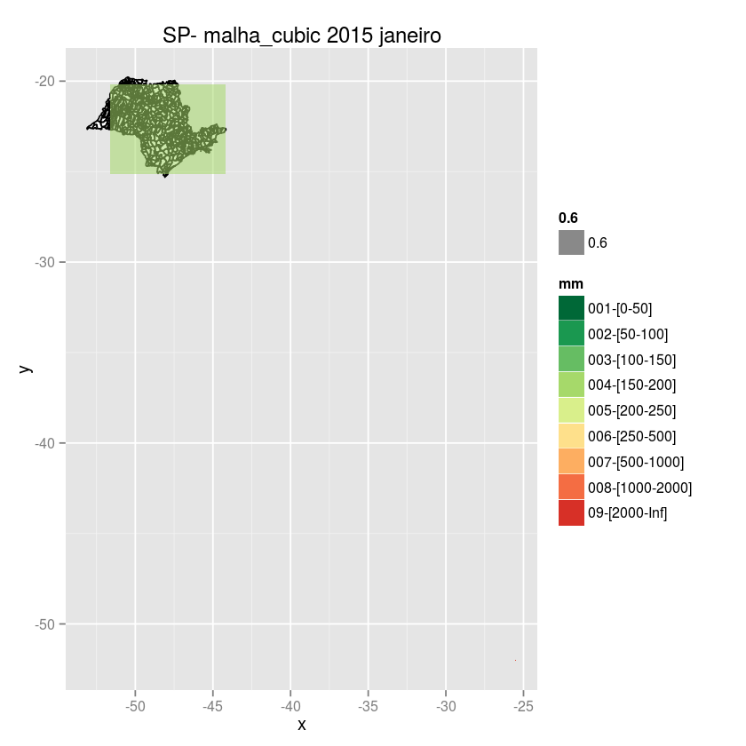

```r
ggplot() %+% gg+aes(x,y)+
      geom_polygon(data=sp.df, aes(long,lat,group=group,fill=""),fill="white",colour="black") +
      geom_tile(aes(fill=brks,alpha=0.6 ))+
      scale_fill_manual("mm",values= color)+
      ggtitle(paste("SP-",modelo,ano,meses[mes],sep=" "))
```

E plotamos sobre a imagem de satélite

[figure not shown]

```r
ggmap(map)  %+% gg+aes(x,y)+
      geom_polygon(data=sp.df, aes(long,lat,group=group ),fill = "white" , colour="white",alpha=0,size= 0.2) +
      geom_tile(aes(fill=brks,alpha=0.6 ))+
      scale_fill_manual("mm",values= color)+
      ggtitle(paste("SP_ -",modelo,ano,meses[mes],sep=" ")) +
      coord_equal()
```

# Resultados

Fazendo isso no ano de 2014 inteiro, temos então o método para cada mês:

[figure not shown]